# CFRM 502, Winter 2020

# Instructor: Bahman Angoshtari

# Solution to Homework 3

$\newcommand\Fc{\mathscr{F}}$ $\newcommand{\eps}{\varepsilon}$ $\newcommand{\Var}{\operatorname{Var}}$ $\newcommand\Cov{\operatorname{Cov}}$ $\newcommand\Corr{\operatorname{Corr}}$ $\newcommand{\sig}{\sigma}$ $\newcommand\Sig{\Sigma}$ $\newcommand{\al}{\alpha}$ $\newcommand{\gam}{\gamma}$ $\newcommand\Gam{\Gamma}$ $\newcommand\lam{\lambda}$ $\newcommand{\Del}{\Delta}$ $\newcommand\tht{\theta}$ $\newcommand\ph{\varphi}$ $\newcommand\om{\omega}$ $\newcommand\Om{\Omega}$ $\newcommand\rb{\bar{r}}$ $\newcommand{\Xb}{\bar{X}}$ $\newcommand{\Yb}{\bar{Y}}$ $\newcommand\Eb{\mathbb{E}}$ $\newcommand\Pb{\mathbb{P}}$ $\newcommand\Qb{\mathbb{Q}}$ $\newcommand\Rb{\mathbb{R}}$ $\newcommand\Zb{\mathbb{Z}}$ $\newcommand\Nb{\mathbb{N}}$ $\newcommand\Av{\textbf{A}}$ $\newcommand\Ev{\textbf{E}}$ $\newcommand\Dv{\textbf{D}}$ $\newcommand\Fv{\textbf{F}}$ $\newcommand\Gv{\textbf{G}}$ $\newcommand\Hv{\textbf{H}}$ $\newcommand\Kv{\textbf{K}}$ $\newcommand\Iv{\textbf{I}}$ $\newcommand\Pv{\textbf{P}}$ $\newcommand\Ov{\textbf{O}}$ $\newcommand\Sv{\textbf{S}}$ $\newcommand\Xv{\textbf{X}}$ $\newcommand\Yv{\textbf{Y}}$ $\newcommand\Zv{\textbf{Z}}$ $\newcommand\av{\mathbf{a}}$ $\newcommand\xv{\mathbf{x}}$ $\newcommand\yv{\mathbf{y}}$ $\newcommand\zv{\mathbf{z}}$ $\newcommand\Cv{\mathbf{C}}$ $\newcommand\mv{\mathbf{m}}$ $\newcommand\nv{\mathbf{n}}$ $\newcommand\pv{\mathbf{p}}$ $\newcommand\sv{\mathbf{s}}$ $\newcommand\wv{\mathbf{w}}$ $\newcommand\Wv{\textbf{W}}$ $\newcommand\alv{{\boldsymbol\al}}$ $\newcommand\betav{{\boldsymbol\beta}}$ $\newcommand\etav{{\boldsymbol\eta}}$ $\newcommand\epsv{{\boldsymbol\varepsilon}}$ $\newcommand\delv{{\boldsymbol\delta}}$ $\newcommand\Lamv{{\boldsymbol\Lambda}}$ $\newcommand\lamv{{\boldsymbol\lambda}}$ $\newcommand\muv{{\boldsymbol\mu}}$ $\newcommand\piv{{\boldsymbol\pi}}$ $\newcommand\Piv{{\boldsymbol\Pi}}$ $\newcommand\Gamv{{\boldsymbol\Gam}}$ $\newcommand\Phiv{{\boldsymbol\Phi}}$ $\newcommand\Sigv{{\boldsymbol\Sig}}$ $\newcommand\ah{\widehat{a}}$ $\newcommand\Pbh{\widehat{\Pb}}$ $\newcommand\phh{\widehat{\varphi}}$ $\newcommand\Ebh{\widehat{\Eb}}$ $\newcommand\Qh{\widehat{Q}}$ $\newcommand\Ih{\widehat{I}}$ $\newcommand\rh{\widehat{r}}$ $\newcommand\pih{\widehat{\pi}}$ $\newcommand\Pih{\widehat{\Pi}}$ $\newcommand\Sigvh{\widehat{\Sigv}}$ $\newcommand\Wh{\widehat{W}}$ $\newcommand\Fh{\widehat{F}}$ $\newcommand\Yh{\widehat{Y}}$ $\newcommand\Zh{\widehat{Z}}$ $\newcommand\Yvh{\widehat{\Yv}}$ $\newcommand\Ah{\widehat{\Ac}}$ $\newcommand\uh{\widehat{u}}$ $\newcommand\vh{\widehat{v}}$ $\newcommand\fh{\widehat{f}}$ $\newcommand\hh{\widehat{h}}$ $\newcommand\Bh{\widehat{B}}$ $\newcommand\Ovh{\widehat{\Ov}}$ $\newcommand\Xvh{\widehat{\Xv}}$ $\newcommand\rhoh{\widehat{\rho}}$ $\newcommand\nuh{\widehat{\nu}}$ $\newcommand\varphih{\widehat{\varphi}}$ $\newcommand\alh{\widehat{\al}}$ $\newcommand\thetah{\widehat{\theta}}$ $\newcommand\betah{\widehat{\beta}}$ $\newcommand\betavh{\widehat{\boldsymbol\beta}}$ $\newcommand\kaph{\widehat{\kappa}}$ $\newcommand\sigh{\widehat{\sigma}}$ $\newcommand\epsh{\widehat{\eps}}$ $\newcommand\epsvh{\widehat{\epsv}}$ $\newcommand\epst{\widetilde{\eps}}$ $\newcommand\muh{\widehat{\mu}}$ $\newcommand\dd{\mathrm{d}}$ $\newcommand\ee{\mathrm{e}}$ $\newcommand{\var}[1]{\text{Var} \left( #1 \right)}$

The following code sets up graphics in the Juypter notebook.

```r
# Setting parameters of the Jupyter notebook
sc = .75
options(repr.plot.width=16*sc,
        repr.plot.height=7*sc,
        repr.plot.pointsize = 13, # Text height in pt
        repr.plot.bg        = 'white',
        repr.plot.antialias = 'gray',
        #nice medium-res DPI
        repr.plot.res       = 300,
        #jpeg quality bumped from default
        repr.plot.quality   = 90,
        #vector font family
        repr.plot.family    = 'serif') # Vector font family. 'sans', 'serif', 'mono' or a specific one
```

# 1.

(5 points) Consider problem 3 of the previous homework about forward rate estimation. The zero-coupon data can be loaded from "HW3-Q1.txt" that is posted with this homework. Use the following code

```r
dat = read.table("HW3-Q1.txt",header=TRUE)
dat = dat[order(dat$T),]
EMP = -diff(log(dat$price))/diff(dat$T)
MAT = dat$T[-1]
```

In the previous Homework, you have fitted the following model,

\begin{align*} \text{EMP}_i = \beta_0 + \beta_1 \,\text{MAT}_i + \beta_2 \,\text{MAT}^2_i + \beta_3\, \text{MAT}^3_i + \eps_i. \end{align*}

In question 3.(e) of Homework 2, you should have found that the residuals of the model above do not have constant variance. Suggest a model to remedy this abnormality. Fit the suggested model and confirm that the issue is resolved (by repeating the regression diagnostic).

**Solution:**

For convenience, let us reproduce the residual plots indicating non-constant variance and non-normality.

```r
fit_HW2Q3d <- lm(EMP ~ MAT + I(MAT^2) + I(MAT^3))
```

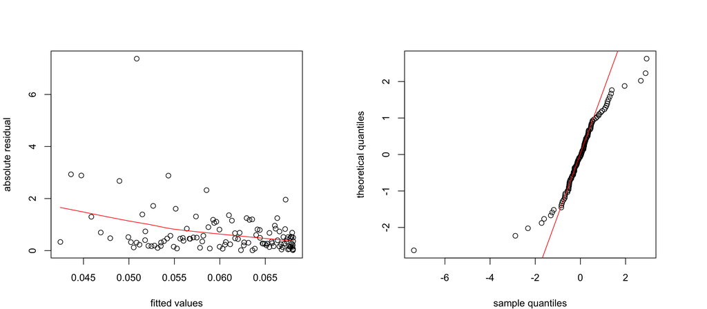

```r
par(mfrow=c(1,2));par(mar=c(4,4,4,4))
plot(fitted(fit_HW2Q3d),abs(rstudent(fit_HW2Q3d)),
     xlab="fitted values", ylab="absolute residual")
fit_loess  = loess(abs(rstudent(fit_HW2Q3d))~ fitted(fit_HW2Q3d),span=1,deg=1)
ord = order(fitted(fit_HW2Q3d))
lines(fitted(fit_HW2Q3d)[ord],fit_loess$fit[ord], col="red")
qqnorm(rstudent(fit_HW2Q3d),datax=T,main="",ylab="sample quantiles",
       xlab="theoretical quantiles")
qqline(rstudent(fit_HW2Q3d),datax=T, col="red")
```

We can use Cox-Box transformation to remedy the issue. For this, we need to fit the following model,

\begin{align*} \text{EMP}_i^\al = \beta_0 + \beta_1 \,\text{MAT}_i + \beta_2 \,\text{MAT}^2_i + \beta_3\, \text{MAT}^3_i + \eps_i. \end{align*}

First, we estimate $\al$ by using a profile MLE plot. Note that the default domain of `boxcox()` function, that is $[-2,2]$ is not appropriate in this case. We need to change the domain to $[2,5]$ by passing the argument `lambda = seq(2, 5, 1/10)`.

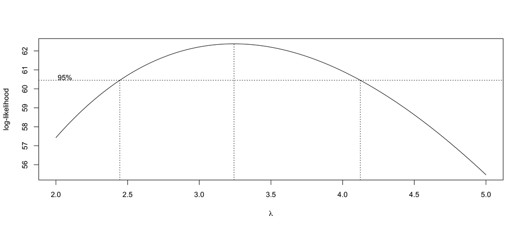

```r
library(MASS)
L_max = boxcox(EMP ~ MAT + I(MAT^2) + I(MAT^3),
               lambda = seq(2, 5, 1/10), ylab="log-likelihood")
```

```r
alphahat = L_max$x[which.max(L_max$y)]
alphahat
```

3.24242424242424

The estimated value is $\alh=3.24$ (using $\alh=3$ is also acceptable). Next, we fit the model

\begin{align*} \text{EMP}_i^{3.24} = \beta_0 + \beta_1 \,\text{MAT}_i + \beta_2 \,\text{MAT}^2_i + \beta_3\, \text{MAT}^3_i + \eps_i \end{align*}

using OLS.

```r
fit_CoxBox <- lm(EMP^alphahat ~ MAT + I(MAT^2) + I(MAT^3))
summary(fit_CoxBox)
```

```
Call:
lm(formula = EMP^alphahat ~ MAT + I(MAT^2) + I(MAT^3))

Residuals:
       Min         1Q     Median         3Q        Max
-5.920e-05 -1.139e-05 -5.310e-07  8.758e-06  6.599e-05

Coefficients:
              Estimate Std. Error t value Pr(>|t|)
(Intercept)  5.472e-05  7.664e-06   7.140 9.96e-11 ***
MAT          6.507e-06  2.231e-06   2.917  0.00427 **
I(MAT^2)     3.337e-07  1.749e-07   1.908  0.05897 .
I(MAT^3)    -2.046e-08  3.900e-09  -5.246 7.43e-07 ***
---
Signif. codes:  0 ‘***’ 0.001 ‘**’ 0.01 ‘*’ 0.05 ‘.’ 0.1 ‘ ’ 1

Residual standard error: 1.935e-05 on 112 degrees of freedom
Multiple R-squared:  0.7929,	Adjusted R-squared:  0.7873
F-statistic: 142.9 on 3 and 112 DF,  p-value: < 2.2e-16
```

Finally, the following residual plots shows that although the issues are not completely resolved, the variance of rstudent seems to be less variable and rstudent looks more normally distributed than before.

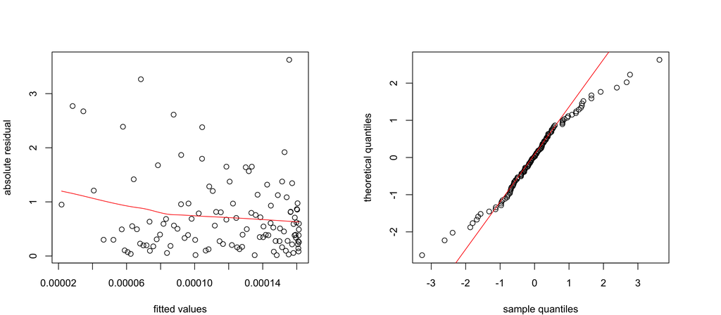

```r
par(mfrow=c(1,2));par(mar=c(4,4,4,4))
plot(fitted(fit_CoxBox),abs(rstudent(fit_CoxBox)),
     xlab="fitted values", ylab="absolute residual")
fit_loess  = loess(abs(rstudent(fit_CoxBox))~ fitted(fit_CoxBox),span=1,deg=1)
ord = order(fitted(fit_CoxBox))
lines(fitted(fit_CoxBox)[ord],fit_loess$fit[ord], col="red")
qqnorm(rstudent(fit_CoxBox),datax=T,main="",ylab="sample quantiles",
       xlab="theoretical quantiles")
qqline(rstudent(fit_CoxBox),datax=T, col="red")
```

# 2.

(5 points) Consider the intraday trading of IBM stock on November 21, 1990, as shown in the graph below. There were 726 transactions on that day during normal trading hours, but only 195 trades resulted in a price change.

[figure not shown]

Let $t_i$ be the time of the $i$-th trade that resulted in a price change. The **"duration"** $\Del\,t_i = t_i - t_{i-1}$ is the time duration between price changes. Furthermore, let $N_i$ be the number of trades in the time interval $(t_{i-1}, t_i)$ that resulted in no price change.

The values of $\{\Del\,t_i\}$ and $\{N_i\}$ are included in the file `HW3-Q2.dat`. To load the data, use the following R code:

```r
dat = read.table("HW3-Q2.dat",header=TRUE)
DUR = dat[,"duration"]
N = dat[,'trades']
```

which stores the values of $\{\Del\,t_i\}$ and $\{N_i\}$ in variables `DUR'' and`N'', respectively.

## (a)

We believe that the conditional probability $\Pb(N_i=0 | \Del\,t_i)$ is a function of $\log(\Del\,t_i)$. So, we propose the following model:

\begin{align*} \Pb(N_i=0 | \Del\,t_i) = \al_0 + \al_1\,\log(\Del\,t_i), \end{align*}

for some unknown constants $\al_0$ and $\al_1$. Estimate $\al_0$ and $\al_1$ using OLS (ordinary least squares).

**Solution:**

We can fit a linear regression model

\begin{align*} Y_i = \al_0 + \al_1 \log(\Delta t_i) + \eps_i, \end{align*}

where we have defined

\begin{align*} Y_i = \begin{cases} 1 & \text{if } N_i=0\\ 0 & \text{if } N_i \ge 1 \end{cases} \end{align*}

```r
Y = ifelse(N==0, 1, 0)
fit_OLS = lm(Y~ log(DUR))
summary(fit_OLS)
```

```
Call:
lm(formula = Y ~ log(DUR))

Residuals:
     Min       1Q   Median       3Q      Max
-0.76735 -0.28884 -0.04206  0.32272  0.78936

Coefficients:
            Estimate Std. Error t value Pr(>|t|)
(Intercept)  1.40425    0.08164   17.20   <2e-16 ***
log(DUR)    -0.23519    0.01927  -12.21   <2e-16 ***
---
Signif. codes:  0 ‘***’ 0.001 ‘**’ 0.01 ‘*’ 0.05 ‘.’ 0.1 ‘ ’ 1

Residual standard error: 0.3762 on 192 degrees of freedom
Multiple R-squared:  0.4369,	Adjusted R-squared:  0.434
F-statistic:   149 on 1 and 192 DF,  p-value: < 2.2e-16
```

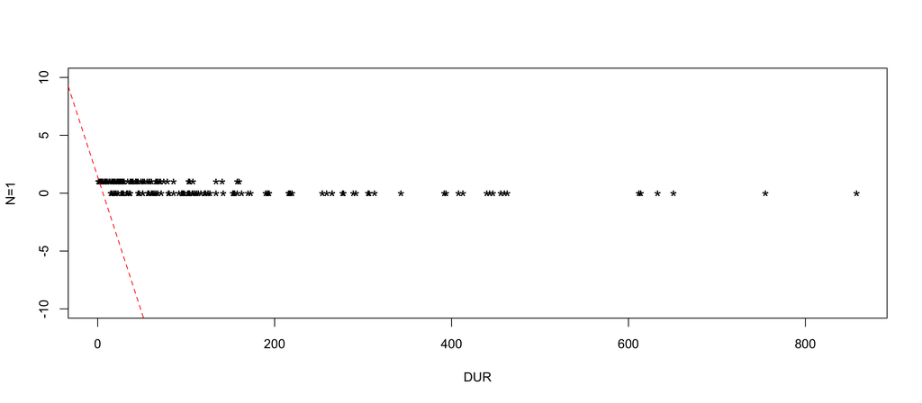

```r
plot(DUR,Y, ylim=c(-10,10),
     pch="*",ylab="N=1",xlab="DUR",cex=1.5)
abline(fit_OLS, lty=2,col="red")
```

## (b)

There is a problem with the model in part (a). Explain the problem. Then, suggest a model to remedy the problem and fit it.

**Solution:** As is clear with the scatter plot above, the regression equation $\al_0 + \al_1\,\log(\Del\,t_i$ is not necessarily a probability, since it does not take value in the interval $[0,1]$. To remedy this issue, we should consider a logit regression

\begin{align*} Y_i = H(\al_0 + \al_1 \log(\Del\,t_i) + \eps_i, \end{align*}

where $H$ is the logistic CDF.

```r
fit_LOGIT = glm(Y~log(DUR), family= binomial(link = "logit"))
summary(fit_LOGIT)
```

```
Call:
glm(formula = Y ~ log(DUR), family = binomial(link = "logit"))

Deviance Residuals:
    Min       1Q   Median       3Q      Max
-2.1049  -0.6270  -0.1826   0.6538   2.0677

Coefficients:
            Estimate Std. Error z value Pr(>|z|)
(Intercept)   6.8040     1.0154   6.701 2.07e-11 ***
log(DUR)     -1.7371     0.2483  -6.997 2.61e-12 ***
---
Signif. codes:  0 ‘***’ 0.001 ‘**’ 0.01 ‘*’ 0.05 ‘.’ 0.1 ‘ ’ 1

(Dispersion parameter for binomial family taken to be 1)

    Null deviance: 267.93  on 193  degrees of freedom
Residual deviance: 157.53  on 192  degrees of freedom
AIC: 161.53

Number of Fisher Scoring iterations: 5
```

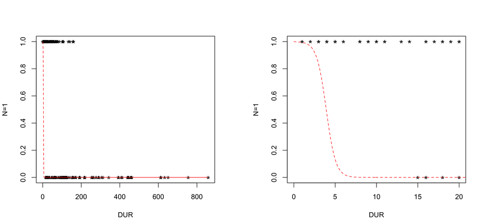

```r
al0 = coef(fit_LOGIT)[[1]]; al1 = coef(fit_LOGIT)[[2]]
DUR_grid = seq(0,max(DUR),.1)
prob = plogis(al0+al1*DUR_grid)
par(mfrow=c(1,2));par(mar=c(4,4,4,4))
plot(DUR,Y, ylim=c(0,1),
     pch="*",ylab="N=1",xlab="DUR",cex=1.5)
lines(DUR_grid, prob, lty=2,col="red")
plot(DUR,Y, ylim=c(0,1), xlim=c(0,20),
     pch="*",ylab="N=1",xlab="DUR",cex=1.5)
lines(DUR_grid, prob, lty=2,col="red")
```

Note that, although this model is not as bad as the one in part a, it is still not a good model. Finding a good classification model (and evaluating them) is beyond the scope of this course.

# 3.

(5 points) The data file `HW3-Q3.txt` to be used for this problem contains 1259 rows giving the daily adjusted closing values of the S\&P 500 index during the period beginning January 4, 2008 and ending December 31, 2012. The goal of this problem is to produce a forecasting for the future changes in the index. We shall use the first 4 years for training of our prediction system and we shall test them on the last year.

Use the following code to load the data

```r
SP = read.table("HW3-Q3.txt",header=TRUE)[,2]
```

Let $\{S_t\}$ denote the index values.

## (a)

(2 points) Construct a local polynomial regression using observations 61-1000 of the index to predict the next weekly change in S\&P 500 using the changes over the last day, the last week, the last 3 weeks and the last 12 weeks as predictors. Assume that every 5 observations is 1 week. Thus, use $S_{t+5}-S_t$ as your response variable and the values $S_{t}-S_{t-1}$, $S_t-S_{t-5}$, $S_t - S_{t-15}$, and $S_t - S_{t-60}$ as predictors.

**Solution:**

We start by creating a dataframe with the response variable $Y_t=S_{t+5}-S_t$ and predictors $Xk=S_t-S_{t-k}$ for $k=1,5,15,60$.

```r
N = length(SP)
empt = rep(NA, N-65)
Dat = data.frame(X1=empt, X5=empt, X15=empt, X60=empt, Y=empt)
lags = c(1,5,15,60)
for (k in 1:4) {
  Dat[,k] = SP[61:(N-5)]-SP[(61-lags[k]):(N-5-lags[k])]
}
Dat[,5] = SP[66:N]-SP[61:(N-5)]
```

As stated in the problem, we take the first 940 observations as the training set (this corresponds to days 61 to 1000) and the rest as the test set.

```r
Dat.train = Dat[1:940,]
Dat.test = Dat[-(1:940),]
```

Next, we fit a loess model using the training data:

```r
lfit=loess(Y~X1+X5+X15+X60, Dat.train,
           control = loess.control(surface = "direct"))
```

## (b)

(1 point) Use the local polynomial regression model estimated in part (a) to predict 254 values of the 5 day increment in the index for the last year of data. That is, predict $S_{t+5}-S_t$ for $t\in{1001, \dots, 1254}$ based on the model fitted in part (a). Compute the sum of squared errors in this predictions.

**Solution:**

We find the sum of square predictions on the test set to be 147,640.8.

```r
Yh = predict(lfit, Dat.test)
sum((Dat.test$Y - Yh)^2)
```

147640.751079908

## (c)

(2 points) Assume that in part (b), instead of using the local polynomial regression, you directly use the last week's change in S\&P 500 index as the prediction for its next weekly change. Find the sum of squared errors of this trivial predictor. Which predictor is better, the one in part (a) or the trivial predictor?

**Solution:**

We obtain $\displaystyle\sum_{t=1001}^1254 \Big[S_{t+5} - S_t - (S_t - S_{t-5})\Big]^2 = \sum_{t=1001}^1254 \Big[Y_t-X5_t\Big]^2 = 357,537.7$

```r
sum((Dat.test$Y - Dat.test$X5)^2)
```

357537.733517213

It seems that the regression model in part (a) is doing a better job in predicting future returns than using the return of the last week as the predictor.

**Extra remarks:** Perhaps, there are some autocorrelation in the returns that the regression model is able to capture. Note, however, that this does not necessarily mean that the regression model has any predictive power.

# 4

(0 points) Solve the following exercises from the textbook, section 21.8.

## (a)

Exercise 3. There is a typo in the definition of $s(x)$. Use the following definition: $s(x) = (x)_+ - 2 (x-1)_+ + (x-2)_+$.

**Solution:**

$s(x)$ is a density function, as it is positive and its integral over $\Rb$ is 1. To obtain the percentile, we proceed as follows. Since $s(x)$ is symmetric with support $(0,2)$ (support of a density is the minimal set outside which the density is zero), and median 1, the \%90 percentile should be in the interval $(1,2)$. For $1<x<2$, we have

\begin{align*} \Pb(X\le x) = 0.5 + \int_1^x (2-t)\dd t = 1 - \frac{(2-x)^2}{2} \end{align*}

Setting $\Pb(X\le x) = 0.9$ yields $x = 2-\sqrt{0.2}\approx 1.553$.

## (b)

Exercise 4.

**Solution:**

We have $s'(x) = 0.65 + 2\,x + 2 (x-1)_+ + 1.2(x-2)_+$ and $s''(x) = 2 + 2(x-1)_+^0 + 1.2(x-2)_+^0$. Therefore,